# Empirical Evaluation of eval in R

# Data

The analysis is being performed on dataset read from file calls.fst.

| path | type | size | permissions | modification_time | user | group | device_id | hard_links | special_device_id | inode | block_size | blocks | flags | generation | access_time | change_time | birth_time |
| --- | --- | --- | --- | --- | --- | --- | --- | --- | --- | --- | --- | --- | --- | --- | --- | --- | --- |
| calls.fst | file | 2.87G | rw-r--r-- | 2020-08-14 11:07:52.243 | aviral | users | 2052 | 1 | 0 | 17889392 | 4096 | 6016296 | 0 | 0 | 2020-08-14 10:55:36.173 | 2020-08-14 11:07:52.243 | 2020-08-14 11:07:52.243 |

| name | Description |
| --- | --- |
| file | File where the `eval` is executed |
| eval_call_id | Unique id of a call |
| expr_parsed_expression | Contains the expression with a call to `parse` if there is one in the `expr` argument somewhere in the call stack. |

# Corpus

# Research Questions

## RQ1: How many evals are there?

There are four kinds of `eval` in the `base` package. Their definitions are shown below.

```r
base::eval <-
    function(expr,
             envir = parent.frame(),
             enclos = if (is.list(envir)||is.pairlist(envir)) parent.frame() else baseenv())
        .Internal(eval(expr, envir, enclos))

base::evalq <-
    function (expr,
              envir = parent.frame(),
              enclos = if (is.list(envir) || is.pairlist(envir)) parent.frame() else baseenv())
        .Internal(eval(substitute(expr), envir, enclos))

base::eval.parent <-
    function (expr, n = 1) {
        p <- parent.frame(n + 1)
        eval(expr, p)
    }

base::local <-
    function (expr, envir = new.env())
        eval.parent(substitute(eval(quote(expr), envir)))
```

```r
callsites_with_srcref <-
    eval_calls %>%
    select(eval_call_srcref) %>%
    n_distinct(na.rm = TRUE)

callsites_without_srcref <-
    eval_calls %>%
    filter(is.na(eval_call_srcref)) %>%
    select(caller_package, caller_function) %>%
    n_distinct()

eval_calls <-
    eval_calls %>%
    mutate(eval_call_srcref = coalesce(eval_call_srcref,
                                       str_c("missing", "::", caller_package, "::", caller_function)))
eval_count_table <-
    eval_calls %>%
    group_by(eval_function, eval_call_srcref) %>%
    summarize(count = n()) %>%
    summarize(call_count = sum(count), callsite_count = n())
nb_eval_calls <- total_call_count <- sum(eval_count_table$call_count)

nb_call_sites <- total_callsite_count <- sum(eval_count_table$callsite_count)

eval_count_table <-
    eval_count_table %>%
    mutate(call_proportion = 100 * call_count / total_call_count,
           callsite_proportion = 100 * callsite_count / total_callsite_count) %>%
    arrange(desc(call_count))

eval_call_proportion <-
    eval_count_table %>%
    filter(eval_function == "eval") %>%
    pull(call_proportion)
```

[output not shown]

We observe that 95.4532408% of the calls are made to the `eval` function.

These `eval` calls originate from 2484 call sites. For the number of call sites, we use line number information attached to the AST by the parser. When it is not available (such as in *base*), we use a combination of `caller_package` and `caller_function`. We assume that: - the combination `caller_package` and `caller_function` is unique - there is only one call site per such `caller_function` This assumption results in a lower bound for the number of unique callsites for eval.

```r
eval_callsite_table <-
    eval_calls %>%
    count(eval_function, caller_package, eval_call_srcref, name = "call_count") %>%
    group_by(eval_function, caller_package) %>%
    summarize(call_count = sum(call_count), callsite_count = n()) %>%
    ungroup()
eval_callsite_table %>%
datatable()
```

|  | eval_function | caller_package | call_count | callsite_count |
| --- | --- | --- | --- | --- |
| 1 | eval | _generator | 2 | 1 |
| 2 | eval | A_generator | 11 | 1 |
| 3 | eval | abind | 86 | 3 |
| 4 | eval | AC_generator | 322 | 1 |
| 5 | eval | AccumulateCallback_generator | 8 | 1 |
| 6 | eval | actuar | 12312 | 40 |
| 7 | eval | Adapter_generator | 36 | 1 |
| 8 | eval | ade4 | 92 | 4 |
| 9 | eval | AER | 58 | 5 |
| 10 | eval | animation | 2 | 1 |

[output cut: 456 more lines]

```r
package_callsite_distribution <-
    eval_callsite_table %>%
    mutate(callsite_count = if_else(callsite_count <= 5, as.character(callsite_count), "> 5")) %>%
    group_by(eval_function, callsite_count) %>%
    summarize(package_count = n())
package_callsite_distribution %>%
datatable()
```

|  | eval_function | callsite_count | package_count |
| --- | --- | --- | --- |
| 1 | eval | &gt; 5 | 85 |
| 2 | eval | 1 | 234 |
| 3 | eval | 2 | 38 |
| 4 | eval | 3 | 18 |
| 5 | eval | 4 | 21 |
| 6 | eval | 5 | 15 |
| 7 | eval.parent | &gt; 5 | 12 |
| 8 | eval.parent | 1 | 18 |
| 9 | eval.parent | 2 | 9 |
| 10 | eval.parent | 3 | 5 |

[output cut: 7 more lines]

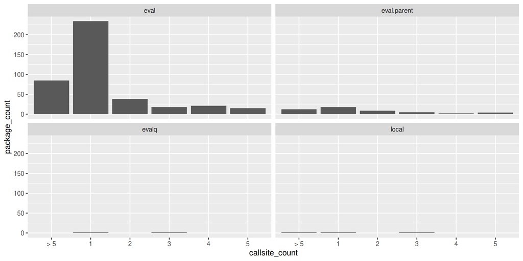

```r
p <-
    package_callsite_distribution %>%
    ggplot(aes(callsite_count, package_count)) +
    geom_col() +
    facet_wrap(vars(eval_function))
p
```

```r
eval_calls %>% filter(caller_package == "base") %>% select(caller_function) %>% n_distinct(na.rm = TRUE)
```

```
## [1] 28
```

**Comparing with `grep`**

Grepping *base* to find eval call sites yields 40 `eval` call sites.

```r
eval_calls %>% filter(caller_package != "base") %>% group_by(caller_package) %>% summarize(nb_call_sites =  n_distinct(eval_call_srcref, na.rm = TRUE)) %>% arrange(desc(nb_call_sites))
```

| caller_package | nb_call_sites |
| --- | --- |
| VGAM | 178 |
| metafor | 153 |
| gamlss | 118 |
| nlme | 110 |
| stats | 84 |
| survey | 77 |
| lattice | 65 |
| actuar | 47 |
| copula | 46 |
| robustbase | 40 |

[output cut: 406 more lines]

We probably forget the generated ones here, but should we count them in the *call sites*?

```r
nb_eval_calls_per_package <- eval_calls %>% group_by(caller_package) %>% summarise(nb_eval_calls_package = n(), per_cent = nb_eval_calls_package / nb_eval_calls * 100) %>% arrange(desc(nb_eval_calls_package))
```

[output not shown]

```r
nb_eval_calls_per_package  %>% datatable()
```

|  | caller_package | nb_eval_calls_package | per_cent |
| --- | --- | --- | --- |
| 1 | base | 7282492 | 75.9264153632487 |
| 2 | ggplot2 | 663200 | 6.91444613587033 |
| 3 | stats | 373946 | 3.89871754331147 |
| 4 | methods | 193990 | 2.02251719827727 |
| 5 | utils | 139549 | 1.45492165834525 |
| 6 | magrittr | 106359 | 1.10888657503774 |
| 7 | plyr | 85047 | 0.886690139501453 |
| 8 | glue | 51892 | 0.541019962126934 |
| 9 | data.table | 51528 | 0.537224940423893 |
| 10 | Stack_generator | 49876 | 0.520001380387015 |

[output cut: 407 more lines]

## Size of expressions as arguments to `eval`

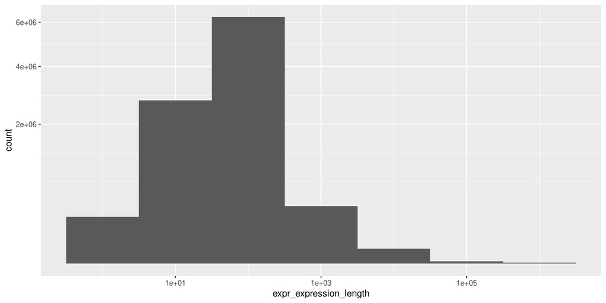

```r
eval_calls %>% ggplot() +
  geom_histogram(aes(x = expr_expression_length), na.rm = TRUE, binwidth=1) +
  scale_x_log10() +  scale_y_sqrt()
```

If we remove the outliers:

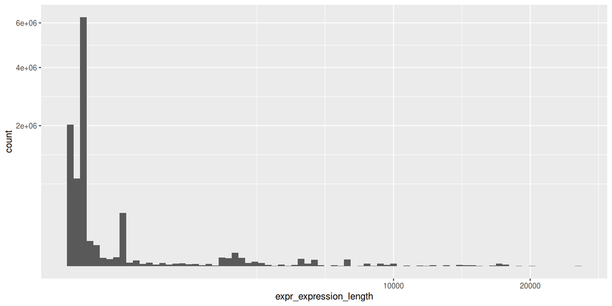

```r
eval_calls %>% filter(expr_expression_length < 25000) %>% ggplot() +
  geom_histogram(aes(x = expr_expression_length), na.rm = TRUE, binwidth=2)  + scale_x_sqrt() +  scale_y_sqrt()
```

**More details**

What about the code size of expressions that seem to be generated? An approximation of *generated* will be no `srcref` and not in `base`.

[figure not shown]

```r
eval_calls %>% filter(is.na(eval_call_srcref), caller_package != "base") %>% ggplot() +
  geom_histogram(aes(x = expr_expression_length), na.rm = TRUE, binwidth=1) + scale_x_sqrt() + scale_y_sqrt()
```

And the average size per package:

```r
eval_calls %>% group_by(caller_package) %>% summarize(average_expr_size = mean(expr_expression_length, na.rm = TRUE)) %>% arrange(desc(average_expr_size))
```

| caller_package | average_expr_size |
| --- | --- |
| doRNG | 559.500000 |
| memoise | 362.183908 |
| utf8 | 280.000000 |
| effects | 186.180000 |
| ROCR | 164.000000 |
| rprojroot | 123.028641 |
| tools | 113.000000 |
| lubridate | 111.681338 |
| np | 109.227273 |
| VGAM | 108.512025 |

[output cut: 407 more lines]

If we look at the maxima, the largest ones are in *base*:

```r
eval_calls %>% group_by(caller_package) %>% summarize(max_expr_size = max(expr_expression_length, na.rm = TRUE)) %>% arrange(desc(max_expr_size))
```

| caller_package | max_expr_size |
| --- | --- |
| base | 1227973 |
| VGAM | 9248 |
| memoise | 804 |
| doRNG | 718 |
| copula | 620 |
| effects | 529 |
| np | 374 |
| utf8 | 280 |
| stats | 278 |
| R.utils | 252 |

[output cut: 407 more lines]

## Amount of computations performed in `eval`

## Aliases of `eval`

# A taxonomy of `eval`

## The operation mix

## Scope (environments)

## Patterns

### Classifying according to the type of the `expr` argument

```r
per_expr_type <- eval_calls %>% count(expr_expression_type)
```

```r
 per_expr_type %>% mutate(per_cent = n / nb_eval_calls * 100 ) %>% arrange(desc(n)) %>% knitr::kable()
```

| expr_expression_type | n | per_cent |
| --- | --- | --- |
| LANGSXP | 7943348 | 82.8164232 |
| SYMSXP | 1648157 | 17.1834934 |
| STRSXP | 7 | 0.0000730 |
| NILSXP | 1 | 0.0000104 |

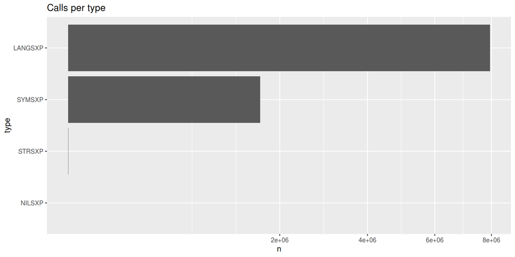

```r
per_expr_type %>% ggplot() +
  geom_col(aes(x = fct_reorder(expr_expression_type, n), y = n)) +
  scale_y_sqrt() +
  coord_flip() +
  labs(title = "Calls per type", y = "n", x = "type" )
```

**Expressions left unchanged by `eval`**

Expressions of types other than `call`, `expression`, `name`, `bytecode` and `promise` are just returned unchanged. Here `language` refers to `call` , `name`to `symbol`. `bytecode` refers to bytecode objects, that are generated by the `compile`function:

```r
typeof(compiler::compile(1+1))
```

```
## [1] "bytecode"
```

```r
changed_evals <- eval_calls %>% mutate(changed =  fct_collapse(expr_expression_type, base_types = c("LANGSXP", "EXPRSXP", "SYMSXP", "PROMSXP", "BCODESXP"))) %>% count(changed) %>% mutate(per_cent = n / nb_eval_calls * 100 )
```

## Provenance

Some `eval` result from parsing text (directly or through a file) with `parse`.

```r
parsed_evals <- eval_calls %>% filter(!is.na(expr_parsed_expression))
nb_parsed_evals <- parsed_evals %>% nrow()
```

There are 107088 such calls, 1.116487%.

```r
nb_parsed_call_sites <- nb_eval_call_sites(parsed_evals)
```

In terms of call sites, there are 310 i.e. 12.4798712%.

**More about `parse`**

We can differentiate further the provenance, i.e. whether the evaluated string comes from `file` or from `text`. However, we can only do it for `parse`, `str2lang` and `str2expression` at the top level of `expr_expression`, not buried in a function call.

```r
parsed_evals_args <- parsed_evals %>% filter(str_detect(expr_parsed_expression, "(parse|str2lang|str2expression)\\(")) %>% mutate(parse_args = map(expr_parsed_expression, extract_args_parse)) %>% unnest_wider(parse_args,  names_sep = "_")
```

```r
parsed_files <- parsed_evals_args %>% filter(!is.na(parse_args_file))
nb_file <- parsed_files %>% nrow()
nb_file_call_sites <- nb_eval_call_sites(parsed_files)
```

```r
parsed_texts <- parsed_evals_args %>% filter(!is.na(parse_args_text) | !is.na(parse_args_s))
nb_text <-  parsed_texts %>% nrow()
nb_text_call_sites <- nb_eval_call_sites(parsed_texts)
```

There are 337 calls with the `file` argument, and 106751 with the `text` argument, i.e. 0.3146945%, and 99.6853055% respectively.

There are 6 call sites with the `file` argument, and 304 with the `text` argument, i.e. 1.9354839%, and 98.0645161% respectively.

## Consistence

# Other faces of `eval`

# Case studies